# Trimester_BFstage

Calen P. Ryan

September 22, 2018

# Setup

## Load all mvals data and packages

# Load reproductive status data and labels and extract those in study:

## Load the data

```r
repro <-read_csv("/home/cpr183/Parity_Pregnancy/Data/repro.final.csv")
labels <-readRDS("/home/cpr183/Parity_Pregnancy/Data/repro.final.labels.rds")
str(labels, list.len=ncol(repro))
```

```
## List of 102
##  $ uncchdid          : NULL
##  $ icsex             : NULL
##  $ blood.draw.date   : chr "Date of blood draw (YYYY-MM-DD)"
##  $ basebrgy          : NULL
##  $ basehhno          : NULL
##  $ basewman          : NULL
##  $ uncmomid          : NULL
##  $ momch07           : NULL
##  $ pregord           : NULL
##  $ pregterm          : NULL
##  $ monthprg          : NULL
##  $ dayprg            : NULL
##  $ yearprg           : NULL
##  $ durmonth          : NULL
```

[output cut: 88 more lines]

## Extract the those with DNAm data

```r
# This should be a function!
ids <-substr(names(mvals)[-1], 2, 6)

repro <-repro %>%
  filter(uncchdid %in% c(ids))

dim(repro)
```

```
## [1] 395 102
```

```r
# It doesn't change here as I used DNAm to figure out who I needed repro data for.
```

## Import genetic data

```r
load("/home/cpr183/ch_assets/Data/CEBU_MDS2(1).RData")
# MDS2

genetic <-rownames_to_column(MDS2, var = "uncchdid"); rm(MDS2)
```

## Import Smoking status

```r
load("/home/cpr183/ch_assets/Data/CEBU_pheno_with_smoking.RData")
# pheno_extended

smoker <-pheno_extended %>%
  select(uncchdid, smoker)

rm(pheno_extended)
```

## Import SES3 variable

```r
SES3 <-read.dta13("/home/cpr183/Parity_Pregnancy/Data/2017-12-01 file for Calen.dta", missing.type= ,generate.factors = T) %>%
  select(uncchdid, SES3)
```

## Merge them all in to create repro.extra

```r
extra <-plyr::join_all(list(genetic, SES3, smoker), by='uncchdid', type='left')
rm(genetic, SES3, smoker)

repro$uncchdid <-as.character(repro$uncchdid)

repro.extra <-left_join(repro, extra, by = "uncchdid");
rm(extra)
```

# Nulliparous to Pregnancy Trimester:

## Calculate a new variable with Null as 0, and trimester as 1,2,3 and Select variables of interest, remove 21116 and 20827, create the matrix

```r
preg.tri.null <-repro.extra %>%
  mutate(null.tri = if_else(is.na(repro.extra$was.preg) | repro.extra$was.preg == FALSE,
                            "0",
                            repro.extra$trimester)) %>%
  filter(reprostat == "pregnant" | reprostat == "nulliparous") %>%
  filter(uncchdid != "21116", uncchdid !="20827") %>%
  select(uncchdid, reprostat, MDS1, MDS2, SES3, null.tri) %>%
  na.omit()

preg.tri.null$null.tri <-as.factor(preg.tri.null$null.tri)
```

## Create the matrix for pregnancy

```r
include <-preg.tri.null$uncchdid

# Search for the uncchdid columns within "no.data" object
matches <-unique( grep(paste(include, collapse="|"),
                       names(mvals), value = TRUE))

# And extract
mvals.drop <-mvals[, which(names(mvals) %in% c("probe", matches))]

dim(mvals.drop)
```

```
## [1] 434728    241
```

```r
################
rowz <-nrow(mvals.drop)
colz <-ncol(mvals.drop[,-1])

matrix.corrected <-matrix(sapply(c(mvals.drop[,-1]), as.numeric), nrow= rowz, ncol=colz , byrow=FALSE)
# So it took at least 11 minutes to create this matrix. Faster than my computer? Maybe not.

matrix.corrected[1:4,1:4]
```

```
##            [,1]       [,2]       [,3]      [,4]
## [1,]  0.8900483  0.7274296  0.5662563  1.133378
## [2,]  4.8286224  4.7067622  5.2763670  5.323965
## [3,]  3.4346407  3.7113485  3.2575779  4.122481
## [4,] -2.0800393 -2.1090707 -1.6835259 -1.869728
```

```r
############

rownames(matrix.corrected) <-mvals[,1]
colnames(matrix.corrected) <-names(mvals.drop[,-1])


# Sanity check - mvals and the created matrix are the same values.
mvals[mvals$probe =="cg00000029", "X22224"]
```

```
## [1] 0.861106
```

```r
matrix.corrected["cg00000029", "X22224"]
```

```
## [1] 0.861106
```

```r
mvals[mvals$probe =="cg03340466", "X22590"]
```

```
## [1] -2.567596
```

```r
matrix.corrected["cg03340466", "X22590"]
```

```
## [1] -2.567596
```

```r
# But are they arranged the same way  (I need uncchdid rows to correspond to columns in matrix.corrected)
identical(substr(colnames(matrix.corrected),2,6), preg.tri.null$uncchdid)
```

```
## [1] FALSE
```

```r
# Nope.


# Reorder:
x <- substr(colnames(matrix.corrected),2,6)

preg.tri.null <-preg.tri.null %>%
  slice(match(x, uncchdid))


identical(substr(colnames(matrix.corrected),2,6), preg.tri.null$uncchdid)
```

```
## [1] TRUE
```

```r
# Good!
```

## Pregnancy Trimester: CORRECTED EWAS

```r
preg.tri.null$null.tri <-as.factor(preg.tri.null$null.tri)

preg.tri.null$null.tri <-relevel(preg.tri.null$null.tri, ref = "0")

# Setup the design matrix. ----
design <- model.matrix(~0 + null.tri +  MDS1 + MDS2 + SES3, data = preg.tri.null);



colnames(design)[1:4]<- c("nulliparous", "first.trimester","second.trimester", "third.trimester")


contrast.matrix<- makeContrasts(N2F = "first.trimester-nulliparous", N2S = "second.trimester-nulliparous", N2T = "third.trimester-nulliparous", levels=design);


# Run the EWAS and smooth the variance ----
preg.tri.null.ewas <-lmFit(matrix.corrected, design, na.action = na.omit)
preg.tri.null.ewas <- contrasts.fit(preg.tri.null.ewas, contrast.matrix)
preg.tri.null.ewas <- eBayes(preg.tri.null.ewas)
preg.tri.null.ewas.var5 <-preg.tri.null.ewas[c(mvals.var5[,1]), ]

# Pull only probes with >5% variability ----
preg.tri.null.ewas.var5.results <-decideTests(preg.tri.null.ewas.var5, adjust.method = "BH", p.value = 0.05)

# Summary data ----
summary(preg.tri.null.ewas.var5.results) %>%
  kable("html") %>%
  kable_styling()
```

|  | N2F | N2S | N2T |
| --- | --- | --- | --- |
| Down | 0 | 300 | 342 |
| NotSig | 110631 | 110321 | 110264 |
| Up | 0 | 10 | 25 |

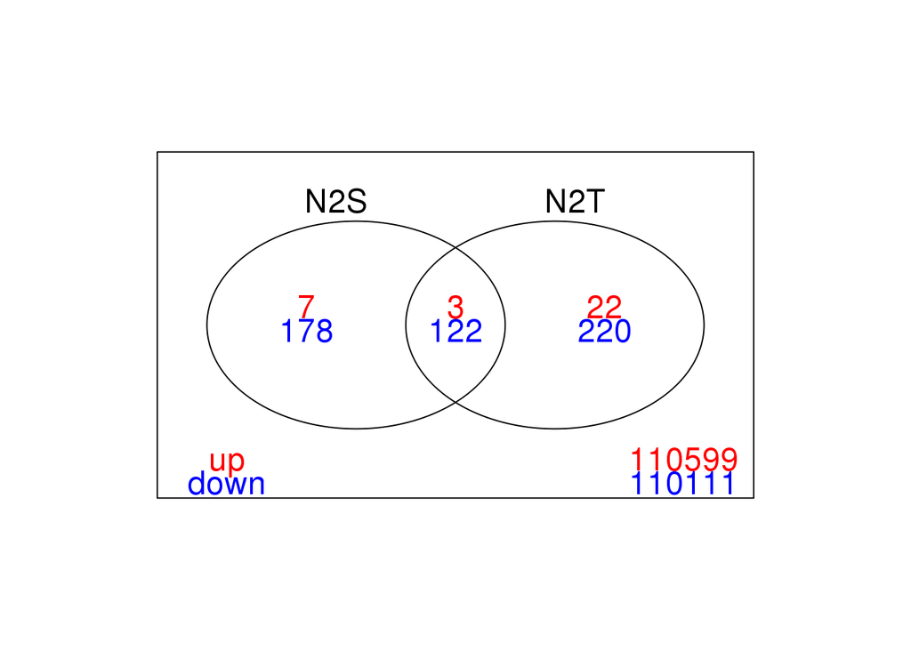

```r
# Ok, for all of them there are SOME significantly different probes...

vennDiagram(preg.tri.null.ewas.var5.results[,c(2,3)], include = c("up", "down"),counts.col = c("red", "blue"))
```

# Pregancy Trimester/Weeks:

## Select variables of interest, remove 21116 and 20827, create the matrix

```r
# Variables =
# uncchdid, was.preg, preg.weeks, trimester, pregord, twins, MDS1, MDS2, SES3, smoker
preg.tri <-repro.extra %>%
  filter(was.preg == TRUE) %>%
  filter(uncchdid != "21116", uncchdid !="20827") %>%
  select(uncchdid, was.preg, preg.weeks, trimester, pregord, twins, MDS1, MDS2, SES3, smoker) %>%
  na.omit()

# Two women were pregnant, but are missing trimester/weeks data.
# 23074 21883
```

## Create the matrix for pregnancy

```r
include <-preg.tri$uncchdid

# Search for the uncchdid columns within "no.data" object
matches <-unique( grep(paste(include, collapse="|"),
                       names(mvals), value = TRUE))

# And extract
mvals.drop <-mvals[, which(names(mvals) %in% c("probe", matches))]

dim(mvals.drop)
```

```
## [1] 434728     66
```

```r
################
rowz <-nrow(mvals.drop)
colz <-ncol(mvals.drop[,-1])

matrix.corrected <-matrix(sapply(c(mvals.drop[,-1]), as.numeric), nrow= rowz, ncol=colz , byrow=FALSE)
# So it took at least 11 minutes to create this matrix. Faster than my computer? Maybe not.

matrix.corrected[1:4,1:4]
```

```
##            [,1]       [,2]      [,3]       [,4]
## [1,]  0.5906652  0.7381583  0.861106  0.6825335
## [2,]  4.7038752  4.7370786  4.433400  4.4342498
## [3,]  3.3101941  3.6174973  3.606736  3.2498535
## [4,] -1.8847939 -2.0115758 -2.054237 -1.7251010
```

```r
############

rownames(matrix.corrected) <-mvals[,1]
colnames(matrix.corrected) <-names(mvals.drop[,-1])


# Sanity check - mvals and the created matrix are the same values.
mvals[mvals$probe =="cg00000029", "X22224"]
```

```
## [1] 0.861106
```

```r
matrix.corrected["cg00000029", "X22224"]
```

```
## [1] 0.861106
```

```r
mvals[mvals$probe =="cg03340466", "X22590"]
```

```
## [1] -2.567596
```

```r
matrix.corrected["cg03340466", "X22590"]
```

```
## [1] -2.567596
```

```r
# But are they arranged the same way  (I need uncchdid rows to correspond to columns in matrix.corrected)
identical(substr(colnames(matrix.corrected),2,6), preg.tri$uncchdid)
```

```
## [1] FALSE
```

```r
# Nope.


# Reorder:
x <- substr(colnames(matrix.corrected),2,6)

preg.tri <-preg.tri %>%
  slice(match(x, uncchdid))


identical(substr(colnames(matrix.corrected),2,6), preg.tri$uncchdid)
```

```
## [1] TRUE
```

```r
# Good!
```

## Pregnancy Trimester: CORRECTED EWAS

```r
preg.tri$trimester <-as.factor(preg.tri$trimester)

preg.tri$trimester <-relevel(preg.tri$trimester, ref = "first.trimester")

# Setup the design matrix. ----
design <- model.matrix(~0 + trimester + pregord + twins + MDS1 + MDS2 + SES3, data = preg.tri);



colnames(design)[1:3]<- c("first.trimester","second.trimester", "third.trimester")


contrast.matrix<- makeContrasts(F2S = "second.trimester-first.trimester", F2T = "third.trimester-first.trimester", S2T = "third.trimester-second.trimester", levels=design);


# Run the EWAS and smooth the variance ----
preg.tri.ewas <-lmFit(matrix.corrected, design, na.action = na.omit)
preg.tri.ewas <- contrasts.fit(preg.tri.ewas, contrast.matrix)
preg.tri.ewas <- eBayes(preg.tri.ewas)
preg.tri.ewas.var5 <-preg.tri.ewas[c(mvals.var5[,1]), ]

# Pull only probes with >5% variability ----
preg.tri.ewas.var5.results <-decideTests(preg.tri.ewas.var5, adjust.method = "BH", p.value = 0.05)

# Summary data ----
summary(preg.tri.ewas.var5.results) %>%
  kable("html") %>%
  kable_styling()
```

|  | F2S | F2T | S2T |
| --- | --- | --- | --- |
| Down | 0 | 15 | 0 |
| NotSig | 110631 | 110616 | 110631 |
| Up | 0 | 0 | 0 |

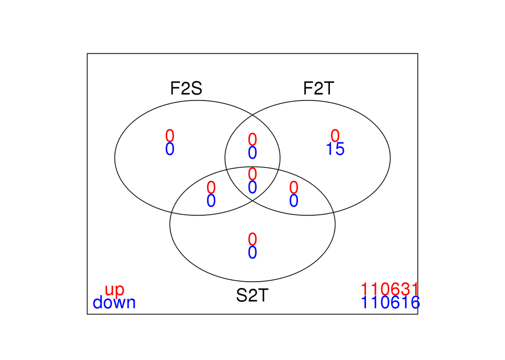

```r
# Ok, for all of them there are SOME significantly different probes...

vennDiagram(preg.tri.ewas.var5.results, include = c("up", "down"),counts.col = c("red", "blue"))
```

## Pregnancy Weeks

```r
design <- model.matrix(~preg.weeks + pregord + twins + MDS1 + MDS2 + SES3, data = preg.tri);


# Run the EWAS and smooth the variance ----
preg.weeks.ewas <-lmFit(matrix.corrected, design, na.action = na.omit)
preg.weeks.ewas <- eBayes(preg.weeks.ewas)
preg.weeks.ewas.var5 <-preg.weeks.ewas[c(mvals.var5[,1]), ]

# Pull only probes with >5% variability ----
preg.weeks.ewas.var5.results <-decideTests(preg.weeks.ewas.var5, adjust.method = "BH", p.value = 0.05)

# Summary data ----
summary(preg.weeks.ewas.var5.results) %>%
  kable("html") %>%
  kable_styling()
```

|  | (Intercept) | preg.weeks | pregord | twins | MDS1 | MDS2 | SES3 |
| --- | --- | --- | --- | --- | --- | --- | --- |
| Down | 36391 | 42 | 0 | 5 | 33 | 26 | 0 |
| NotSig | 15089 | 110582 | 110631 | 110613 | 110550 | 110589 | 110631 |
| Up | 59151 | 7 | 0 | 13 | 48 | 16 | 0 |

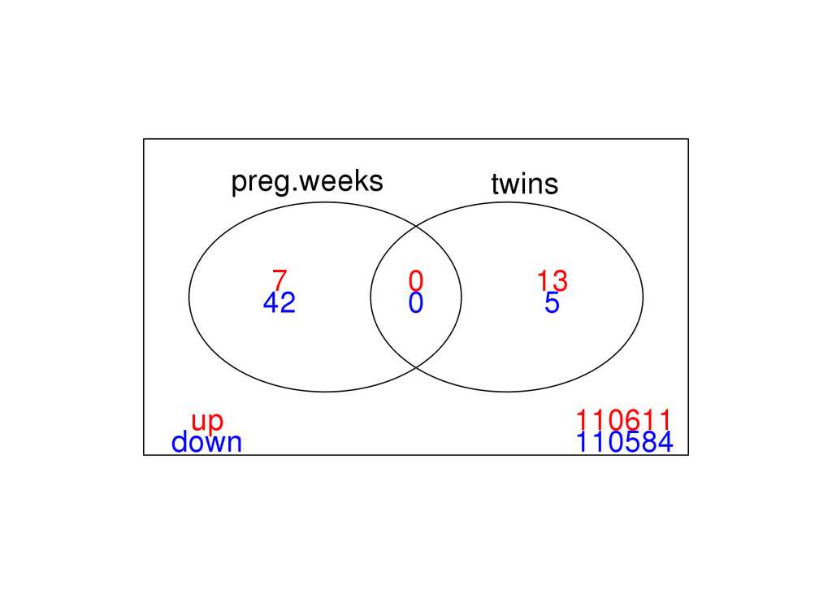

```r
# Ok, for all of them there are SOME significantly different probes...

vennDiagram(preg.weeks.ewas.var5.results[,c(2,4)], include = c("up", "down"),counts.col = c("red", "blue"))
```

# Nulliparous to Breastfeeding:

## Calculate a new variable with Null as 0, and bf as 1,2,3 and Select variables of interest, remove 21116 and 20827, create the matrix

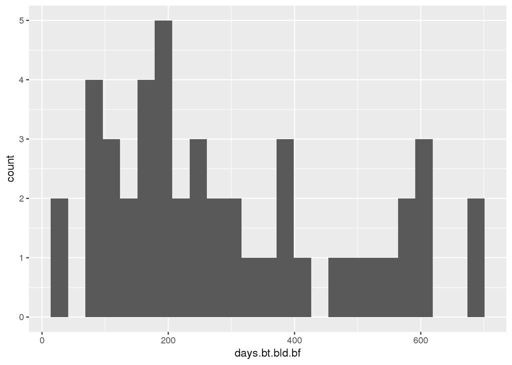

```r
repro.extra %>%
  filter(was.lact != FALSE) %>%
  select(uncchdid, was.lact, days.bt.bld.bf, pregord) %>%
  ggplot(aes(days.bt.bld.bf)) +
  geom_histogram(bins = 25)
```

```r
# All these I have calculated are was.lact, which was calculated using those where blood sample was between conception and bf.term, so I'm good.

repro.extra %>% select(was.lact, reprostat, oldmilk, oldsolid, blood.draw.date, days.bt.bld.bf, bf.term) %>% print(n = Inf)
```

```
## # A tibble: 395 x 7
##     was.lact reprostat     oldmilk oldsolid blood.draw.date days.bt.bld.bf
##     <lgl>    <chr>           <int>    <int> <date>                   <dbl>
##   1 NA       nulliparous        NA       NA 2005-03-13                NA
##   2 NA       nulliparous        -9       -9 2005-03-15                NA
##   3 NA       nulliparous        NA       NA 2005-03-14                NA
##   4 NA       nulliparous        NA       NA 2005-03-16                NA
##   5 NA       nulliparous        NA       NA 2005-03-15                NA
##   6 NA       nulliparous        NA       NA 2005-09-20                NA
##   7 NA       nulliparous        NA       NA 2005-03-20                NA
##   8 NA       nulliparous        NA       NA 2005-09-04                NA
##   9 NA       nulliparous        NA       NA 2005-09-30                NA
##  10 NA       nulliparous        -9       -9 2005-04-06                NA
##  11 NA       nulliparous        NA       NA 2005-04-04                NA
##  12 NA       nulliparous        -9       -9 2005-03-31                NA
```

[output cut: 384 more lines]

```r
# So even though it says oldmik and oldsolid are how old the baby was when introducing supplementary milk or solid foods IN MONTHS, 99% sure oldmilk is in days, oldsolid is in months.Otherwise why would people be introducing supplementary solid foods WAAAY before milk supplementation?!


# Make a categorical variable of BF
repro.extra$bf.cat <- cut(repro.extra$days.bt.bld.bf, breaks=c(0, 180, 360, Inf), labels=c("zero_6mo","sixmo_12mo","over_1yr"))



## Update bf.status so that it's not missing

lact.null <-repro.extra %>%
  mutate(null.bf = if_else(is.na(repro.extra$was.lact) | repro.extra$was.lact == FALSE,
                            "0",
                            as.character(repro.extra$bf.cat))) %>%
  filter(reprostat == "breastfeeding" | reprostat == "nulliparous") %>%
  filter(uncchdid != "21116", uncchdid !="20827") %>%
  select(uncchdid, reprostat, MDS1, MDS2, SES3, null.bf)




lact.null <-lact.null %>%
  na.omit()


lact.null %>% print(n = Inf)
```

```
## # A tibble: 219 x 6
##     uncchdid reprostat         MDS1     MDS2      SES3 null.bf
##     <chr>    <chr>            <dbl>    <dbl>     <dbl> <chr>
##   1 20040    nulliparous    -3.05   -17.6     2.09     0
##   2 20047    nulliparous    -7.22     2.65   -0.640    0
##   3 20068    nulliparous    10.8     -1.86   -2.28     0
##   4 20073    nulliparous    11.6     -4.76    0.372    0
##   5 20083    nulliparous     2.56     0.313   1.01     0
##   6 20105    nulliparous     4.28     5.12    0.617    0
##   7 20109    nulliparous    -4.71    -9.25   -0.237    0
##   8 20173    nulliparous    10.4    -11.8     1.96     0
##   9 20232    nulliparous    10.8      2.82    2.81     0
##  10 20283    nulliparous    24.0     -6.51   -0.732    0
##  11 20326    nulliparous    -0.710    6.18   -0.0967   0
##  12 20328    nulliparous     3.83    -6.46   -1.03     0
```

[output cut: 207 more lines]

## Create the matrix for NULL-BF

```r
include <-lact.null$uncchdid

# Search for the uncchdid columns within "no.data" object
matches <-unique( grep(paste(include, collapse="|"),
                       names(mvals), value = TRUE))

# And extract
mvals.drop <-mvals[, which(names(mvals) %in% c("probe", matches))]

dim(mvals.drop)
```

```
## [1] 434728    220
```

```r
################
rowz <-nrow(mvals.drop)
colz <-ncol(mvals.drop[,-1])

matrix.corrected <-matrix(sapply(c(mvals.drop[,-1]), as.numeric), nrow= rowz, ncol=colz , byrow=FALSE)
# So it took at least 11 minutes to create this matrix. Faster than my computer? Maybe not.

matrix.corrected[1:4,1:4]
```

```
##            [,1]       [,2]       [,3]       [,4]
## [1,]  0.8900483  0.6715614  0.7274296  0.5662563
## [2,]  4.8286224  4.5243875  4.7067622  5.2763670
## [3,]  3.4346407  3.5909012  3.7113485  3.2575779
## [4,] -2.0800393 -1.9913411 -2.1090707 -1.6835259
```

```r
############

rownames(matrix.corrected) <-mvals[,1]
colnames(matrix.corrected) <-names(mvals.drop[,-1])


# Sanity check - mvals and the created matrix are the same values.
mvals[mvals$probe =="cg00000029", "X20483"]
```

```
## [1] 0.3471688
```

```r
matrix.corrected["cg00000029", "X20483"]
```

```
## [1] 0.3471688
```

```r
mvals[mvals$probe =="cg03340466", "X20313"]
```

```
## [1] -2.534862
```

```r
matrix.corrected["cg03340466", "X20313"]
```

```
## [1] -2.534862
```

```r
# But are they arranged the same way  (I need uncchdid rows to correspond to columns in matrix.corrected)
identical(substr(colnames(matrix.corrected),2,6), lact.null$uncchdid)
```

```
## [1] FALSE
```

```r
# Nope.


# Reorder:
x <- substr(colnames(matrix.corrected),2,6)

lact.null <-lact.null %>%
  slice(match(x, uncchdid))


identical(substr(colnames(matrix.corrected),2,6), lact.null$uncchdid)
```

```
## [1] TRUE
```

```r
# Good!
```

## BF category: CORRECTED EWAS

```r
lact.null$null.bf <-as.factor(lact.null$null.bf)


lact.null$null.bf <-factor(lact.null$null.bf, levels = c("0", "zero_6mo", "sixmo_12mo", "over_1yr"))



# Setup the design matrix. ----
design <- model.matrix(~0 + null.bf  +  MDS1 + MDS2 + SES3, data = lact.null);



colnames(design)[1:4]<- c("nulliparous", "zero_6mo","sixmo_12mo", "over_1yr")


contrast.matrix<- makeContrasts(N2F = "zero_6mo-nulliparous",
                                N2S = "sixmo_12mo-nulliparous",
                                N2T = "over_1yr-nulliparous", levels=design);


# Run the EWAS and smooth the variance ----
lact.null.ewas <-lmFit(matrix.corrected, design, na.action = na.omit)
lact.null.ewas <- contrasts.fit(lact.null.ewas, contrast.matrix)
lact.null.ewas <- eBayes(lact.null.ewas)
lact.null.ewas.var5 <-lact.null.ewas[c(mvals.var5[,1]), ]

# Pull only probes with >5% variability ----
lact.null.ewas.var5.results <-decideTests(lact.null.ewas.var5, adjust.method = "BH", p.value = 0.05)

# Summary data ----
summary(lact.null.ewas.var5.results) %>%
  kable("html") %>%
  kable_styling()
```

|  | N2F | N2S | N2T |
| --- | --- | --- | --- |
| Down | 8 | 1 | 0 |
| NotSig | 110382 | 110630 | 110631 |
| Up | 241 | 0 | 0 |

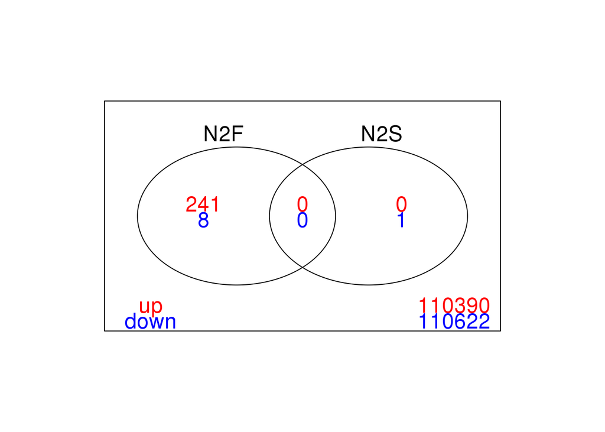

```r
# Ok, for all of them there are SOME significantly different probes...

vennDiagram(lact.null.ewas.var5.results[,c(1,2)], include = c("up", "down"),counts.col = c("red", "blue"))
```

# Breastfeeding Days:

## Select variables of interest, remove 21116 and 20827, create the matrix

```r
# Variables =
# uncchdid, was.preg, preg.weeks, trimester, pregord, twins, MDS1, MDS2, SES3, smoker
lact.stage <-repro.extra %>%
  filter(was.lact == TRUE) %>%
  filter(uncchdid != "21116", uncchdid !="20827") %>%
  select(uncchdid, was.lact, days.bt.bld.bf, pregord, twins, MDS1, MDS2, SES3) %>%
  na.omit()

# 16 women missing breastfeeding data...
```

## Create the matrix for breastfeeding

```r
include <-lact.stage$uncchdid

# Search for the uncchdid columns within "no.data" object
matches <-unique( grep(paste(include, collapse="|"),
                       names(mvals), value = TRUE))

# And extract
mvals.drop <-mvals[, which(names(mvals) %in% c("probe", matches))]

dim(mvals.drop)
```

```
## [1] 434728     47
```

```r
################
rowz <-nrow(mvals.drop)
colz <-ncol(mvals.drop[,-1])

matrix.corrected <-matrix(sapply(c(mvals.drop[,-1]), as.numeric), nrow= rowz, ncol=colz , byrow=FALSE)
# So it took at least 11 minutes to create this matrix. Faster than my computer? Maybe not.

matrix.corrected[1:4,1:4]
```

```
##            [,1]       [,2]       [,3]      [,4]
## [1,]  0.6715614  0.6467447  0.6102629  0.885802
## [2,]  4.5243875  4.9133638  5.1107074  4.953235
## [3,]  3.5909012  3.4254456  3.0178142  3.611821
## [4,] -1.9913411 -2.4596500 -2.0238298 -1.643150
```

```r
############

rownames(matrix.corrected) <-mvals[,1]
colnames(matrix.corrected) <-names(mvals.drop[,-1])


# Sanity check - mvals and the created matrix are the same values.
mvals[mvals$probe =="cg00000029", "X20373"]
```

```
## [1] 0.6715614
```

```r
matrix.corrected["cg00000029", "X20373"]
```

```
## [1] 0.6715614
```

```r
mvals[mvals$probe =="cg03340466", "X20917"]
```

```
## [1] -2.308452
```

```r
matrix.corrected["cg03340466", "X20917"]
```

```
## [1] -2.308452
```

```r
# But are they arranged the same way  (I need uncchdid rows to correspond to columns in matrix.corrected)
identical(substr(colnames(matrix.corrected),2,6), lact.stage$uncchdid)
```

```
## [1] FALSE
```

```r
# Nope.


# Reorder:
x <- substr(colnames(matrix.corrected),2,6)

lact.stage <-lact.stage %>%
  slice(match(x, uncchdid))


identical(substr(colnames(matrix.corrected),2,6), lact.stage$uncchdid)
```

```
## [1] TRUE
```

```r
# Good!
```

## Breastfeeding days

```r
design <- model.matrix(~days.bt.bld.bf + pregord + twins + MDS1 + MDS2 + SES3, data = lact.stage);


# Run the EWAS and smooth the variance ----
lact.days.ewas <-lmFit(matrix.corrected, design, na.action = na.omit)
lact.days.ewas <- eBayes(lact.days.ewas)
lact.days.ewas.var5 <-lact.days.ewas[c(mvals.var5[,1]), ]

# Pull only probes with >5% variability ----
lact.days.ewas.var5.results <-decideTests(lact.days.ewas.var5, adjust.method = "BH", p.value = 0.05)

# Summary data
summary(lact.days.ewas.var5.results) %>%
  kable("html") %>%
  kable_styling()
```

|  | (Intercept) | days.bt.bld.bf | pregord | twins | MDS1 | MDS2 | SES3 |
| --- | --- | --- | --- | --- | --- | --- | --- |
| Down | 32615 | 0 | 0 | 4 | 0 | 0 | 0 |
| NotSig | 22238 | 110631 | 110631 | 110590 | 110631 | 110629 | 110631 |
| Up | 55778 | 0 | 0 | 2 | 0 | 2 | 0 |

```r
# Ok, for all of them there are SOME significantly different probes...
```

## Calculate a new variable with Null as 0, and trimester as 1,2,3 and Select variables of interest, remove 21116 and 20827, create the matrix

```r
preg.tri.null <-repro.extra %>%
  mutate(null.tri = if_else(is.na(repro.extra$was.preg) | repro.extra$was.preg == FALSE,
                            "0",
                            repro.extra$trimester)) %>%
  filter(reprostat == "pregnant" | reprostat == "nulliparous") %>%
  filter(uncchdid != "21116", uncchdid !="20827") %>%
  select(uncchdid, reprostat, MDS1, MDS2, SES3, null.tri) %>%
  na.omit()

preg.tri.null$null.tri <-as.factor(preg.tri.null$null.tri)
```

## Create the matrix for pregnancy

```r
include <-preg.tri.null$uncchdid

# Search for the uncchdid columns within "no.data" object
matches <-unique( grep(paste(include, collapse="|"),
                       names(mvals), value = TRUE))

# And extract
mvals.drop <-mvals[, which(names(mvals) %in% c("probe", matches))]

dim(mvals.drop)
```

```
## [1] 434728    241
```

```r
################
rowz <-nrow(mvals.drop)
colz <-ncol(mvals.drop[,-1])

matrix.corrected <-matrix(sapply(c(mvals.drop[,-1]), as.numeric), nrow= rowz, ncol=colz , byrow=FALSE)
# So it took at least 11 minutes to create this matrix. Faster than my computer? Maybe not.

matrix.corrected[1:4,1:4]
```

```
##            [,1]       [,2]       [,3]      [,4]
## [1,]  0.8900483  0.7274296  0.5662563  1.133378
## [2,]  4.8286224  4.7067622  5.2763670  5.323965
## [3,]  3.4346407  3.7113485  3.2575779  4.122481
## [4,] -2.0800393 -2.1090707 -1.6835259 -1.869728
```

```r
############

rownames(matrix.corrected) <-mvals[,1]
colnames(matrix.corrected) <-names(mvals.drop[,-1])


# Sanity check - mvals and the created matrix are the same values.
mvals[mvals$probe =="cg00000029", "X22224"]
```

```
## [1] 0.861106
```

```r
matrix.corrected["cg00000029", "X22224"]
```

```
## [1] 0.861106
```

```r
mvals[mvals$probe =="cg03340466", "X22590"]
```

```
## [1] -2.567596
```

```r
matrix.corrected["cg03340466", "X22590"]
```

```
## [1] -2.567596
```

```r
# But are they arranged the same way  (I need uncchdid rows to correspond to columns in matrix.corrected)
identical(substr(colnames(matrix.corrected),2,6), preg.tri.null$uncchdid)
```

```
## [1] FALSE
```

```r
# Nope.


# Reorder:
x <- substr(colnames(matrix.corrected),2,6)

preg.tri.null <-preg.tri.null %>%
  slice(match(x, uncchdid))


identical(substr(colnames(matrix.corrected),2,6), preg.tri.null$uncchdid)
```

```
## [1] TRUE
```

```r
# Good!
```

# Annotation of hits

## Load annotation

```r
source('/home/cpr183/Basic-Scripts/Load_annotation.R')
```

## Pull the probes from pregnancy trimester

```r
preg.hits <-rownames_to_column(topTable(preg.tri.ewas.var5, coef=c("F2T"), adjust="BH", number = Inf, p.value = 0.05), "probe")$probe

annot %>%
  filter(probe %in% preg.hits) %>%
  select(probe, UCSC_REFGENE_NAME, UCSC_REFGENE_GROUP, ENHANCER)
```

```
##         probe       UCSC_REFGENE_NAME    UCSC_REFGENE_GROUP ENHANCER
## 1  cg00868074                 ZCCHC14                 3'UTR       NA
## 2  cg03450635 FAM198B;FAM198B;FAM198B TSS200;TSS1500;TSS200       NA
## 3  cg04439557                    NADK                  Body       NA
## 4  cg06545761                 ZCCHC14                 3'UTR       NA
## 5  cg06817454                                                   TRUE
## 6  cg07248223                    CCR7                  Body       NA
## 7  cg08122070                    NADK                  Body       NA
## 8  cg08996521               CISH;CISH       TSS1500;TSS1500       NA
## 9  cg09981464                 ZCCHC14                 3'UTR       NA
## 10 cg16047279                    CCR7                  Body       NA
## 11 cg19821297                                                   TRUE
## 12 cg20995564               ZEB2;ZEB2             Body;Body     TRUE
## 13 cg26960939                    CCR7                  Body       NA
## 14 cg27138901           CLEC2D;CLEC2D           3'UTR;3'UTR       NA
## 15 cg27469606                   SBNO2                 5'UTR       NA
```

```r
annot %>%
  filter(probe %in% preg.hits) %>%
  select(UCSC_REFGENE_NAME) %>%
  group_by(UCSC_REFGENE_NAME) %>%
  count(n()) %>%
  arrange(-n)
```

```
## # A tibble: 9 x 3
## # Groups:   UCSC_REFGENE_NAME [9]
##   UCSC_REFGENE_NAME       `n()`     n
##   <chr>                   <int> <int>
## 1 CCR7                        3     3
## 2 ZCCHC14                     3     3
## 3 ""                          2     2
## 4 NADK                        2     2
## 5 CISH;CISH                   1     1
## 6 CLEC2D;CLEC2D               1     1
## 7 FAM198B;FAM198B;FAM198B     1     1
## 8 SBNO2                       1     1
## 9 ZEB2;ZEB2                   1     1
```

The top genes by trimester: 15

ZCCHC14[^1] CCR7[^2] NADK[^3]

FAM198B[^4] CISH[^5] ZEB2[^6] CLEC2D[^7] SBNO2[^8]

Actually every single one in trimester is replicated in weeks.

## Pull the probes for Pregnancy Weeks

```r
preg.hits.weeks <-rownames_to_column(topTable(preg.weeks.ewas.var5, coef=c("preg.weeks"), adjust="BH", number = Inf, p.value = 0.05), "probe")$probe

annot %>%
  filter(probe %in% preg.hits.weeks) %>%
  select(probe, UCSC_REFGENE_NAME, UCSC_REFGENE_GROUP, ENHANCER)
```

```
##         probe       UCSC_REFGENE_NAME    UCSC_REFGENE_GROUP ENHANCER
## 1  cg00336867                                                     NA
## 2  cg00750518                   DCTN2                  Body       NA
## 3  cg00868074                 ZCCHC14                 3'UTR       NA
## 4  cg01059398                 TNFSF10                  Body     TRUE
## 5  cg01243312         MIR128-1;R3HDM1             Body;Body       NA
## 6  cg01409343                  TMEM49                  Body       NA
## 7  cg02716826            SUGT1P1;AQP3             Body;Body     TRUE
## 8  cg02812767                   LOXL1               TSS1500       NA
## 9  cg03450635 FAM198B;FAM198B;FAM198B TSS200;TSS1500;TSS200       NA
## 10 cg03741653          BMP1;BMP1;BMP1        Body;Body;Body       NA
## 11 cg04439557                    NADK                  Body       NA
## 12 cg06096446             TULP4;TULP4             Body;Body     TRUE
## 13 cg06545761                 ZCCHC14                 3'UTR       NA
## 14 cg06817454                                                   TRUE
```

[output cut: 35 more lines]

```r
annot %>%
  filter(probe %in% preg.hits.weeks) %>%
  select(UCSC_REFGENE_NAME) %>%
  group_by(UCSC_REFGENE_NAME) %>%
  count(n()) %>%
  arrange(-n) %>%
  print(n = Inf)
```

```
## # A tibble: 34 x 3
## # Groups:   UCSC_REFGENE_NAME [34]
##    UCSC_REFGENE_NAME       `n()`     n
##    <chr>                   <int> <int>
##  1 ""                          7     7
##  2 CCR7                        3     3
##  3 TMEM49                      3     3
##  4 ZCCHC14                     3     3
##  5 NADK                        2     2
##  6 SBNO2                       2     2
##  7 TRIM27                      2     2
##  8 ADAMTS1                     1     1
##  9 ATP6V1B2                    1     1
## 10 BMP1;BMP1;BMP1              1     1
## 11 BTLA;BTLA                   1     1
```

[output cut: 23 more lines]

Top genes by Pregnancy weeks (subset): CCR7 [^9] [TMEM49](https://www.genecards.org/cgi-bin/carddisp.pl?gene=VMP1) ZCCHC14 [^10] NADK [^11] SBNO2 [^12] TRIM27

Also appearing by trimester FAM198B[^13] CISH[^14] ZEB2[^15] CLEC2D[^16]

## Pull the probes for Twins

```r
preg.hits.twins <-rownames_to_column(topTable(preg.weeks.ewas.var5, coef=c("twins"), adjust="BH", number = Inf, p.value = 0.05), "probe")$probe

annot %>%
  filter(probe %in% preg.hits.twins) %>%
  select(probe, UCSC_REFGENE_NAME, UCSC_REFGENE_GROUP, ENHANCER)
```

```
##         probe             UCSC_REFGENE_NAME            UCSC_REFGENE_GROUP
## 1  cg00386035
## 2  cg01719995                         USP38                       TSS1500
## 3  cg04117113
## 4  cg04389994                      CCDC109A                          Body
## 5  cg05580141                      C12orf41                          Body
## 6  cg06097557 FYTTD1;KIAA0226;FYTTD1;FYTTD1 TSS1500;5'UTR;TSS1500;TSS1500
## 7  cg07033722                     PPT1;PPT1                   3'UTR;3'UTR
## 8  cg07462863           EVI2A;NF1;NF1;EVI2A         3'UTR;Body;Body;3'UTR
## 9  cg07772516                   TMOD2;TMOD2                   3'UTR;3'UTR
## 10 cg08539965                        EIF4G3                         5'UTR
## 11 cg11494508             HEPACAM2;HEPACAM2                   TSS200;Body
## 12 cg12865675                     CANX;CANX                   3'UTR;3'UTR
## 13 cg13991834                       BCL2L15                        TSS200
## 14 cg14685356             SYNE1;SYNE1;SYNE1              Body;TSS200;Body
```

[output cut: 23 more lines]

```r
annot %>%
  filter(probe %in% preg.hits.twins) %>%
  select(UCSC_REFGENE_NAME) %>%
  group_by(UCSC_REFGENE_NAME) %>%
  count(n()) %>%
  arrange(-n) %>%
  print(n = Inf)
```

```
## # A tibble: 17 x 3
## # Groups:   UCSC_REFGENE_NAME [17]
##    UCSC_REFGENE_NAME             `n()`     n
##    <chr>                         <int> <int>
##  1 ""                                2     2
##  2 BCL2L15                           1     1
##  3 C12orf41                          1     1
##  4 CANX;CANX                         1     1
##  5 CCDC109A                          1     1
##  6 CDK18;CDK18;CDK18                 1     1
##  7 EBF3                              1     1
##  8 EIF4G3                            1     1
##  9 EVI2A;NF1;NF1;EVI2A               1     1
## 10 FYTTD1;KIAA0226;FYTTD1;FYTTD1     1     1
## 11 HEPACAM2;HEPACAM2                 1     1
## 12 KRT80;KRT80                       1     1
## 13 PPT1;PPT1                         1     1
## 14 SYNE1;SYNE1;SYNE1                 1     1
## 15 TMOD2;TMOD2                       1     1
## 16 USP38                             1     1
## 17 VARS2;VARS2;VARS2                 1     1
```

## Pull the probes for BreastFeeding Categories

```r
null.lact.hits <-rownames_to_column(topTable(lact.null.ewas.var5, coef=c("N2F"), adjust="BH", number = Inf, p.value = 0.05), "probe")$probe

annot %>%
  filter(probe %in% null.lact.hits) %>%
  select(probe, UCSC_REFGENE_NAME, UCSC_REFGENE_GROUP, ENHANCER)
```

```
##          probe
## 1   cg00005619
## 2   cg00142670
## 3   cg00412772
## 4   cg00424690
## 5   cg00425710
## 6   cg00452882
## 7   cg00484711
## 8   cg00525683
## 9   cg00561634
## 10  cg00610692
## 11  cg00619207
## 12  cg00686823
## 13  cg00748072
## 14  cg00812761
```

[output cut: 985 more lines]

```r
annot %>%
  filter(probe %in% null.lact.hits) %>%
  select(UCSC_REFGENE_NAME) %>%
  group_by(UCSC_REFGENE_NAME) %>%
  count(n()) %>%
  arrange(-n) %>%
  print(n = Inf)
```

```
## # A tibble: 179 x 3
## # Groups:   UCSC_REFGENE_NAME [179]
##     UCSC_REFGENE_NAME                                          `n()`     n
##     <chr>                                                      <int> <int>
##   1 ""                                                            52    52
##   2 C6orf154                                                       4     4
##   3 ST5;ST5;ST5                                                    4     4
##   4 RPTOR;RPTOR                                                    3     3
##   5 VTI1A                                                          3     3
##   6 COL23A1                                                        2     2
##   7 DENND2D                                                        2     2
##   8 LRRK1                                                          2     2
##   9 MLNR                                                           2     2
##  10 MYO10                                                          2     2
##  11 RIMS3                                                          2     2
```

[output cut: 168 more lines]

# Overlap between pregnancy trimesters and early lactation?

## Build hits

```r
null.preg.tri.hits.N2S <-rownames_to_column(topTable(preg.tri.null.ewas.var5, coef=c("N2S"), adjust="BH", number = Inf, p.value = 0.05), "probe")$probe

null.preg.tri.hits.N2T <-rownames_to_column(topTable(preg.tri.null.ewas.var5, coef=c("N2T"), adjust="BH", number = Inf, p.value = 0.05), "probe")$probe

null.lact.hits <-rownames_to_column(topTable(lact.null.ewas.var5, coef=c("N2F"), adjust="BH", number = Inf, p.value = 0.05), "probe")$probe
```

```
## [1] 1
```

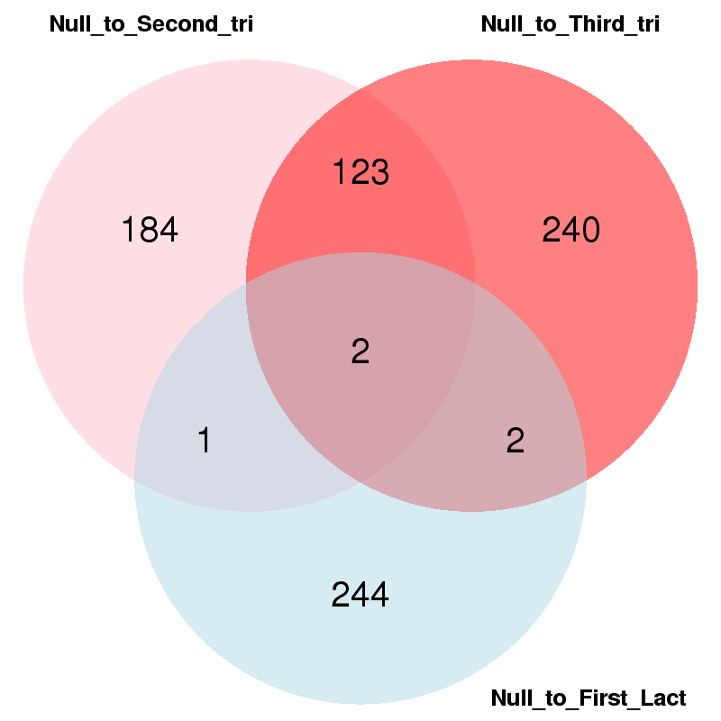

```r
VennDiagram::venn.diagram(
  x = list(null.preg.tri.hits.N2S, null.preg.tri.hits.N2T, null.lact.hits),
  category.names = c("Null_to_Second_tri", "Null_to_Third_tri", "Null_to_First_Lact"),
  filename = '/home/cpr183/Parity_Pregnancy/Results/Figures/Big_groups_compare.png',
        output = TRUE ,
        imagetype="png" ,
        height = 800 ,
        width = 800 ,
        resolution = 300,
        compression = "lzw",
        lwd = 2,
        lty = 'blank',
        fill = c('pink', 'red', 'lightblue'),
        cex = 0.8,
        fontfamily = "sans",
        cat.cex = 0.5,
        cat.fontface = "bold",
        cat.default.pos = "outer",
        cat.pos = c(-20, 20, 135),
        cat.dist = c(0.055, 0.055, 0.085),
        cat.fontfamily = "sans",
        rotation = 1
        )
```

[^1]: These hits were found in both pregnancy trimester and weeks of pregnancy EWAS
[^2]: These hits were found in both pregnancy trimester and weeks of pregnancy EWAS
[^3]: These hits were found in both pregnancy trimester and weeks of pregnancy EWAS
[^4]: These hits were found in both pregnancy trimester and weeks of pregnancy EWAS
[^5]: These hits were found in both pregnancy trimester and weeks of pregnancy EWAS
[^6]: These hits were found in both pregnancy trimester and weeks of pregnancy EWAS
[^7]: These hits were found in both pregnancy trimester and weeks of pregnancy EWAS
[^8]: These hits were found in both pregnancy trimester and weeks of pregnancy EWAS
[^9]: These hits were found in both pregnancy trimester and weeks of pregnancy EWAS
[^10]: These hits were found in both pregnancy trimester and weeks of pregnancy EWAS
[^11]: These hits were found in both pregnancy trimester and weeks of pregnancy EWAS
[^12]: These hits were found in both pregnancy trimester and weeks of pregnancy EWAS
[^13]: These hits were found in both pregnancy trimester and weeks of pregnancy EWAS
[^14]: These hits were found in both pregnancy trimester and weeks of pregnancy EWAS
[^15]: These hits were found in both pregnancy trimester and weeks of pregnancy EWAS
[^16]: These hits were found in both pregnancy trimester and weeks of pregnancy EWAS